# PG11: A Crash Course in Microbiome Analysis

Christopher A. Brown

May 17, 2023

This report was built with R version 4.3.0.

# I. Introduction

Welcome to the R coding portion of the hands-on introduction to studying the lung microbiome. In this tutorial we’ll demonstrate how R can be used to perform data manipulation, modeling, visualization, and reporting as part of our analysis workflow. If you have not already done so, please download R, RStudio, and the necessary packages. See this [guide](https://github.com/cb-42/ATS2023_PG11) for more details.

## 1.1 Why RStudio?

There are many quality of life features that aid in making your time spent coding more efficient and your work reproducible. For example, many keyboard shortcuts exist in RStudio Desktop for common tasks, such as executing code or adding new code chunks. For a full list of shortcuts, navigate to the top of RStudio’s interface, select **Tools** then **Keyboard Shortcuts Help**. There are many other useful features, though a full discussion of these is outside the scope of this presentation.

## 1.2 Why R Markdown?

- Easily combine narrative, code, statistics, and visualizations in one document.
- Reproducibility
- Generate high quality reports in a variety of formats: PDF, HTML, slides. We’ll walk through the creation of an HTML report.

## 1.3 Navigating RStudio Desktop & an R Markdown script

R Markdown documents consist of narrative of text such as this sentence, and code chunks such as the section directly below. Code chunks are enclosed within two pairs of three backticks. For reference a backtick is denoted by: `` ` ``.

```r
# This is an example of a comment within a code chunk.
# The # symbol means that any text following it should not be treated as R code.
# When R code is run in a code chunk the resulting output will be displayed inline - that is, within the document - just below the current code chunk.
# Any lines without a # symbol comprise actual R code and  will be executed when this code chunk is run.
# To execute an entire code chunk: left click the green arrow in upper right of this section:
# Alternatively, left click on the following line with R code, then use: cmd + enter (mac), ctrl + enter (pc). This will run a single line rather than
# the entire chunk.
paste("Welcome to ATS 2023, PG11: A Crash Course in Microbiome Analysis")
```

```
## [1] "Welcome to ATS 2023, PG11: A Crash Course in Microbiome Analysis"
```

## 1.4 Brief notes on R code syntax, best practices

These following suggested practices will aid you as you begin coding. We’ll also demonstrate these throughout the tutorial.

- Include comments explaining what your code does. The primary beneficiary will likely be your future self!
- To view the help documentation for a function or library, use a `?` and `function_name`, such as `?ggplot`.
- Give objects meaningful, formulaic names to signal or recall what is inside the object. This is not always easy when creating dozens of variables.
- Utilize the following syntax where appropriate: `package_name::function_name()`
  - The main reason to do this is to avoid calling the wrong function of the same name from another package, as we’ll see with `dplyr::select()`. It also informs users which library a function is from.
- Become familiar with and make use of the pipe operator: `%>%`. The pipe passes the output of a function as input to another function. This can drastically improve the efficiency of your time spent coding, and is a natural fit for data wrangling workflows. We’ll see several examples of this in action.

# II. Data Acquisition & Preparation

We will be using 16S data resulting from mothur processing and metadata that was previously generated. All of this data is available [here](https://github.com/dicksonlunglab/mouse_lung_microbiome_variability/tree/master/mouse_lung_microbiome_heterogeneity).

## 2.1 Library Load

Before we begin bringing in the data to begin our analysis, we need to load the libraries that we’ll use. Libraries contain additional code (primarily in the form of functions) and/or data that extend R’s base functionality. A good practice is to keep a code chunk near the top of your script that contains all the libraries that are utilized in the analysis, so it’s easy to keep track of all of the dependencies that your code has.

```r
# This section contains typical libraries used in these analyses

# I. universal data wrangling and visualization
library(tidyverse)      # ggplot2, dplyr, purrr, forcats, stringr... and other packages. See https://tidyverse.tidyverse.org/

# II. machine learning & analysis packages
library(vegan)          # decostand(), metaMDS(), scores(), rda(), ordispider(), adonis()
library(mvabund)        # mvabund(), manyglm() # Note: mvabund modeling section is commented out by default due to its time cost
library(randomForest)   # randomForest()

# III. formatting, plotting
library(scales)         # used in formatting relative abundance % labels; unit_format()
library(RColorBrewer)   # brewer.pal() for generating custom palettes
library(knitr)          # kable(), for displaying nicer tables in html/pdf output
```

## 2.2 Variable setup

It’s often beneficial to include a code chunk containing variables that store settings to be used throughout a workflow. Let’s first establish a seed for reproducibility.

Secondly, we’ll create a custom color palette for use in certain visualizations. It’s beneficial to define and organize variables early in the workflow, as code that relies on the palette won’t run if the palette hasn’t been defined. Thus it is best to define the color palette before creating any visualizations.

```r
rnd_seed = 8947 # seed to be used throughout workflow where functions would otherwise yield pseudo-random output
# for PCA ordinations; choose an 9 value pal. covering maximum number of factor levels (conditions) within variable of interest
pcapal <- brewer.pal(9,"Set1")
```

## 2.3 16S Data

Next we’ll bring in the 16S data from two mothur files which have the raw counts and taxonomy information.

```r
# For ease of use, place the processed 16S data files of interest into the same directory as your current RStudio project
# Best practices:
# 1) keep a separate project for each experiment or combination of experiments
# 2) include a data folder within the project's directory to keep source files organized; also somewhat mitigates the risk of modifying them inadvertently
# For this tutorial, all sources files can be found in the data subfolder.

# I. Read in .shared file (counts of sequences assigned to OTU #s)
# The following code includes basic processing with selection of OTUs > 0.1 % of the population
# First read in the data, treating the first row as column names
otu_raw <- read.table("data/Heterogeneity.shared.txt", row.names = 2, header = TRUE, stringsAsFactors = FALSE)
otu_trim <- otu_raw[, -c(1:2)] # drop the first 2 columns
otu_trim <- as.matrix(otu_trim)
otu_tmp <- vegan::decostand(otu_trim, "total") * 100 # standardization
otu_trim[which(otu_tmp < 0.1)] <- 0
otu_good <- otu_trim[, which(colSums(otu_trim) > 0)] # keep only OTUs remaining after setting quantities under 0.1 to 0

# Trim _S from end of rownames(otu_good); it may be useful to keep these well identifiers in some analyses
# Also clean up extra underscores and Xs from rownames
rownames(otu_good) <- str_remove(rownames(otu_good), "_S\\d+") %>% # before assigning output to rownames(), it's piped below
  str_replace_all(pattern = "[_X]+", replacement="_") %>%
  str_remove(pattern="_$")


# It's a good idea to inspect data regularly with tools such as dim(), str(), head(), tail(), summary(), etc. This will help catch errors
dim(otu_good) # dim(otu_good)[1] observations (samples) x dim(otu_good)[2] features (OTUs above .1% population threshold)
```

```
## [1] 192 730
```

```r
otu_good[1:20, 1:10] # Examine first 20 rows, 10 columns. Try using other means for glimpsing the data, such as str(otu_good).
```

```
##                           Otu00001 Otu00002 Otu00003 Otu00004 Otu00005 Otu00006
## Control_01_AE                  101        0        1        3        0        1
## Control_02_AE                  404        0      179        0        0        0
## Control_03_AE                    2        0        0        0        0        1
## Control_04_AE                 6165        0     4734        0        0        0
## Control_05_AE                16177        0     2331        0        0        0
## Control_06_AE                38002        0        0        0        0        0
## Control_07_AE                 1307        0      133        0       11     2346
## Control_08_AE                   11        0       67        3        6       72
## Control_01_Blank                86        0        0        0        0       54
## Control_02_Blank              9763        0        0     1251        0       55
## Control_03_Blank               106        0     1075        0        0        0
## Control_04_Blank              2026        0      487        3        3        0
## Tissue_CharRiv1_10_Cecum         0        0        0        0        0        0
## Tissue_CharRiv1_10_Lung          0        0        1        0        0        0
## Tissue_CharRiv1_10_Nasal       225        0     4515        0        0        0
## Tissue_CharRiv1_10_Tongue        0    37998        0        0        0        0
## Tissue_CharRiv1_01_Cecum         0        0     1169        0        0        0
## Tissue_CharRiv1_01_Lung         27       19        2        9        0        0
## Tissue_CharRiv1_01_Nasal      1028      203      443        0    20631      115
## Tissue_CharRiv1_01_Tongue        0    19405        0        0        0        0
##                           Otu00007 Otu00008 Otu00009 Otu00010
## Control_01_AE                    0        3        0        1
## Control_02_AE                    0        1        0        0
## Control_03_AE                    0        0        3        0
## Control_04_AE                    0        0        0        0
## Control_05_AE                    0        0        0        0
## Control_06_AE                    0        0        0        0
## Control_07_AE                    0        0        0        0
## Control_08_AE                    0        1        2        0
## Control_01_Blank                 0        0        0        0
## Control_02_Blank                 0        0        0        0
## Control_03_Blank                 0        0        0      406
## Control_04_Blank                 0        3        0        0
## Tissue_CharRiv1_10_Cecum       872        0      104        0
## Tissue_CharRiv1_10_Lung          2        1        0        0
## Tissue_CharRiv1_10_Nasal         0        0        0        0
## Tissue_CharRiv1_10_Tongue        0        0        0        0
## Tissue_CharRiv1_01_Cecum      5643        0      201        0
## Tissue_CharRiv1_01_Lung          0        0        1        3
## Tissue_CharRiv1_01_Nasal         0        0        0     2596
## Tissue_CharRiv1_01_Tongue        0        0        0        0
```

```r
# II. Read in cons.taxonomy (for each OTU: contains taxonomic identifiers down to Genus level, if classification was possible via mothur)
# Note that OTUs are in rows here rather than columns
# 2 imports are required due to the combination of 2 different separators in the source file
tax1 <- read.table("data/Heterogeneity.0.03.cons.taxonomy.txt", sep = "\t", row.names = 1, header = TRUE, colClasses = c("character", "numeric", "character"))
tax2 <- read.table("data/Heterogeneity.0.03.cons.taxonomy.txt", sep = ";", skip = 1, col.names = c("", "Phylum", "Class", "Order", "Family", "Genus", ""),
                   stringsAsFactors = FALSE) %>%
    dplyr::select(-c(1, 7)) %>% # drop columns 1 and 7
    purrr::map_df(stringr::str_replace, "\\(.*.\\)", "") %>% # this essentially trims '(100)' and such
    purrr::map_df(as.factor) # turns all remaining columns into factor type variables
otu_taxonomy <- data.frame(OTU = rownames(tax1), Size = tax1[, 1], tax2, stringsAsFactors = FALSE) # combine first and second import
rownames(otu_taxonomy) <- rownames(tax1)

# trim otu_taxonomy based on OTUs in otu_good
otu_good_taxonomy <- otu_taxonomy[otu_taxonomy$OTU %in% colnames(otu_good), ] %>%
  droplevels() # Remove factor levels that have no values remaining due to removal
rownames(otu_good_taxonomy) <- intersect(rownames(otu_taxonomy), colnames(otu_good))
# otu_good_taxonomy <- as.data.frame(otu_good_taxonomy) # redundant in this case - we've already got a dataframe object

dim(otu_good_taxonomy) # Displays number of rows and columns
```

```
## [1] 730   7
```

```r
otu_good_taxonomy # Examine the taxonomy dataframe. The first 10 OTUs coincide with the glimpse we took of otu_good.
```

|  | OTU | Size | Phylum | Class | Order | Family | Genus |
| --- | --- | --- | --- | --- | --- | --- | --- |
| Otu00001 | Otu00001 | 317956 | Firmicutes | Bacilli | Bacillales | Bacillaceae_1 | Bacillus |
| Otu00002 | Otu00002 | 258489 | Firmicutes | Bacilli | Lactobacillales | Streptococcaceae | Streptococcus |
| Otu00003 | Otu00003 | 209867 | Proteobacteria | Gammaproteobacteria | Enterobacteriales | Enterobacteriaceae | Escherichia_Shigella |
| Otu00004 | Otu00004 | 125716 | Proteobacteria | Gammaproteobacteria | Pseudomonadales | Moraxellaceae | Acinetobacter |
| Otu00005 | Otu00005 | 108281 | Proteobacteria | Gammaproteobacteria | Enterobacteriales | Enterobacteriaceae | unclassified |
| Otu00006 | Otu00006 | 89444 | Proteobacteria | Betaproteobacteria | Burkholderiales | Comamonadaceae | Pelomonas |
| Otu00007 | Otu00007 | 87663 | Deferribacteres | Deferribacteres | Deferribacterales | Deferribacteraceae | Mucispirillum |
| Otu00008 | Otu00008 | 62908 | Bacteroidetes | Flavobacteria | Flavobacteriales | Flavobacteriaceae | Elizabethkingia |
| Otu00009 | Otu00009 | 58566 | Bacteroidetes | Bacteroidia | Bacteroidales | Porphyromonadaceae | unclassified |
| Otu00010 | Otu00010 | 56861 | Firmicutes | Bacilli | Bacillales | Staphylococcaceae | Staphylococcus |

[output cut: 720 more lines]

```r
# Note: we leverage the df_print: paged RMarkdown YAML option to be able to look through the dataframe in HTML output.
```

## 2.4 Metadata

In order to group our samples by factors of interest, we’ll also need metadata or environmental data. Here we illustrate how that can be done.

```r
# In this section, we'll load in metadata/environmental data, and/or create it

## Load approach using metadata from github repo
meta_df <- read.table("data/Heterogeneity.metadata.txt", sep = "\t", header = TRUE, stringsAsFactors = TRUE,
                       colClasses = c("specimen" = "character"))
# Note that this will create factors out of all text (string) columns, except for specimen which we enforced as character type.
# Factors are useful for 'reagent_tissue', 'litter', 'vendor', 'mouse', 'tissue_type', and 'cage' variables.

otu_df <- data.frame(meta_df, vegan::decostand(otu_good, "total") * 100, stringsAsFactors = FALSE) # standardize OTUs in our otu dataframe


### Optional reading: Examples of metadata creation using regular expressions (regex) in a tidyverse pipeline ###
# Note that extracting metadata from sample names is much easier if naming conventions are consistent in terms of spelling and placement
# otu_df <- data.frame(decostand(otu_good, "total") * 100, Sample_name = row.names(otu_good), stringsAsFactors = FALSE) %>%
#   # Create Specimen_ctrl from first string of characters prior to first "_"
#   mutate(Specimen_ctrl = factor(case_when(str_detect(Sample_name, "^AE_") ~ "AE",
#                                        str_detect(Sample_name, "^Blank\\d_") ~ "Empty",
#                                        str_detect(Sample_name, "^Heparin_") ~ "Heparin",
#                                        str_detect(Sample_name, "^HomogCtrl_") ~ "HomogCtrl",
#                                        str_detect(Sample_name, "^IsoCtrl_") ~ "IsoCtrl",
#                                        str_detect(Sample_name, "^LPS_") ~ "LPS",
#                                        str_detect(Sample_name, "^PerfusionPBS_") ~ "PBS",
#                                        str_detect(Sample_name, "^WATERD|^waterC") ~ "WaterNeg",
#                                        str_detect(Sample_name, "^mock[CD]") ~ "Mock",
#                                        str_detect(Sample_name, "^[:alnum:]+") ~ str_extract(Sample_name, "^[:alnum:]+")), # for experimental groups, place after other steps as this regex fills in values for controls (may or may not be ideal)
#                                 levels = c("CR1", "CR2", "JAX1", "JAX2", "AE", "Empty", "Heparin", "HomogCtrl", "IsoCtrl", "LPS", "PBS", "WaterNeg", "Mock")
#                 )
#          ) %>%
#   # Create Organ
#   mutate(Organ = factor(case_when(str_detect(Sample_name, "_CECUM_") ~ "Cecum",
#                                   str_detect(Sample_name, "_LUNG_HOMOG") ~ "Lung",
#                                   str_detect(Sample_name, "_NASAL_") ~ "Nasal",
#                                   str_detect(Sample_name, "_TONGUE_") ~ "Tongue"),
#                         levels = c("Nasal", "Tongue", "Lung", "Cecum")
#                 ) # sum(is.na(otu_df$Organ)) returns 32 (as expected, controls have NA in this column)
#          ) %>%
#   # Create Mouse
#   mutate(Mouse = as.numeric(str_extract(Sample_name, "(?<=(CR\\d|JAX\\d)_)\\d+") # numbers correspond to mice if a CR or JAX specimen
#               ) # sum(is.na(otu_df$Mouse)) returns 32 (as expected, the controls have NA in this column)
#          ) %>%
#   # metadata columns at front, followed by all of the count data
#   dplyr::select(Sample_name:Mouse, everything())
#   # note that the data is in wide format
#
# otu_df$Specimen_ctrl %>% table() %>% sum() # 192: all samples/rows are accounted for
# otu_df$Organ %>% summary() %>% sum() # ditto; 32 NAs for organs
```

Here is a glimpse of the metadata, done by randomly sampling 10 rows. Both lines need to be run at the same time for the seed to be used properly.

```r
# The following code uses our seed for reproducibility, then randomly samples and displays 10 rows from the metadata dataframe
set.seed(rnd_seed) # feel free to explore other samples by changing the seed to another integer
dplyr::sample_n(meta_df, 10)
```

|  | specimen | reagent_tissue | litter | vendor | mouse | tissue_type | log_IL1a | VEGF | FGF | IL17 | IL2 | MIG | IL4 | cage | IL1a |
| --- | --- | --- | --- | --- | --- | --- | --- | --- | --- | --- | --- | --- | --- | --- | --- |
| 104 | Tissue_Jackson1_10_Lung | Tissue | Jackson1 | Jackson_Labs | JL1_10 | Lung | 0.3075530 | 88.60229 | 701.0632 | 0.0000000 | 6.366398 | 10.266051 | 0.000000 | JL_1_2 | 2.030266 |
| 6 | Control_06_AE | Control | None | None | 6 | AE | NA | NA | NA | NA | NA | NA | NA | NA | NA |
| 55 | Tissue_CharRiv2_10_Nasal | Tissue | CharRiv2 | Charles_River | CR2_10 | Nasal | 0.2469431 | 140.09801 | 928.8854 | 0.0000000 | 12.390619 | 6.258374 | 0.000000 | CR_2_2 | 1.765806 |
| 149 | Tissue_Jackson2_01_Nasal | Tissue | Jackson2 | Jackson_Labs | JL2_1 | Nasal | 1.2029272 | 108.51380 | 670.0865 | 0.9023904 | 18.831688 | 33.136069 | 19.045106 | JL_2_1 | 15.956115 |
| 28 | Tissue_CharRiv1_03_Tongue | Tissue | CharRiv1 | Charles_River | CR1_3 | Tongue | 0.9113146 | 57.86691 | 613.7807 | 0.7339794 | 13.997830 | 25.041943 | 9.534462 | CR_1_1 | 8.152947 |
| 12 | Control_04_Blank | Control | None | None | 4 | Blank | NA | NA | NA | NA | NA | NA | NA | NA | NA |
| 137 | Tissue_Jackson1_08_Nasal | Tissue | Jackson1 | Jackson_Labs | JL1_8 | Nasal | 0.8178750 | 117.57414 | 794.7882 | 0.2689379 | 12.646821 | 41.245965 | 5.873649 | JL_1_2 | 6.574685 |
| 129 | Tissue_Jackson1_06_Nasal | Tissue | Jackson1 | Jackson_Labs | JL1_6 | Nasal | 0.7716683 | 77.42988 | 659.5486 | 0.0000000 | 10.541102 | 12.948673 | 0.000000 | JL_1_2 | 5.911100 |
| 182 | Tissue_Jackson2_09_Tongue | Tissue | Jackson2 | Jackson_Labs | JL2_9 | Tongue | 0.4940576 | 105.29141 | 635.8324 | 0.0000000 | 10.186462 | 19.658484 | 0.000000 | JL_2_2 | 3.119303 |
| 32 | Tissue_CharRiv1_04_Tongue | Tissue | CharRiv1 | Charles_River | CR1_4 | Tongue | 0.9318212 | 60.11756 | 607.1103 | 1.5358429 | 15.868581 | 30.433518 | 13.258239 | CR_1_1 | 8.547148 |

# III. Absolute Abundance

It’s important to quantify the total bacterial load, typically done as one of the first steps in our analysis.

## 3.1 ddPCR

We’ll show an example using ddPCR, though first we need to load the data.

```r
# The readxl library is installed along with tidyverse, but is not loaded with library(tidyverse). We can however access
# the read_xlsx function without loading readxl as shown below with the readxl::read_xlsx notation.
spec_abs <- readxl::read_xlsx("data/16S_EvaGreen__Heterogeneity1_Data.xlsx", sheet = 2) %>%
  dplyr::select(Sample_name = `Sample Name`, DNA_copies_per_ul = `Copies/ul DNA`) %>% # Rename the two columns of interest, retain only these columns
  dplyr::filter(str_detect(Sample_name, "LUNG")) # Keep only the lung tissue samples

ctrl_abs <- readxl::read_xlsx("data/16S_EvaGreen__Heterogeneity1Ctrls_030618.xlsx", sheet = 2) %>%
  dplyr::select(Sample_name = `Sample Name`, DNA_copies_per_ul = `Copies/ul Sample`) %>% # Rename the two columns of interest, retain only these columns
  drop_na() %>% # drop rows with missing values
  data.frame() # Avoid tibble indexing warning for next step (As of tibble 3.0.0)
# Round up 0.57 DNA_copies to 1 (HomogCtrl_2)
ctrl_abs[ctrl_abs[, "DNA_copies_per_ul"] < 1, "DNA_copies_per_ul"] <- 1

abs_df <- full_join(spec_abs, ctrl_abs, by = c("Sample_name", "DNA_copies_per_ul")) %>% # We could also use bind_rows() or rbind() in this scenario since we renamed the columns to match. However, for more complex operations, it's safer to use a join function and specify the key columns.
  mutate(Type = factor(case_when( # We need to create a factor containing the types of samples for creating separate bars in an upcoming visualization.
    str_detect(Sample_name, "LUNG") ~ "Lung", # When the Sample_name contains LUNG, assign Lung as the value in the new Type column
    TRUE ~ str_extract(Sample_name, "^[:alpha:]+") # Otherwise, determine a value based on the sequence of letters that occur at the start of the Sample_name
  ), levels = c("AE", "HomogCtrl", "IsoCtrl", "NTC", "Lung"))) # Assign an appropriate order for the factor

# We also need to compute the averages and error
avg_abs_df <- abs_df %>%
  group_by(Type) %>% # Before computing an average, identify categories for aggregation. In this case, they're contained within the Type variable we created.
  summarize(mean_DNA_copies = mean(DNA_copies_per_ul), SEM = sqrt(var(DNA_copies_per_ul)/length(DNA_copies_per_ul)), .groups = "drop") # Create mean and SEM columns
```

Next, we’ll examine this ddPCR data using a bar chart created with `ggplot`.

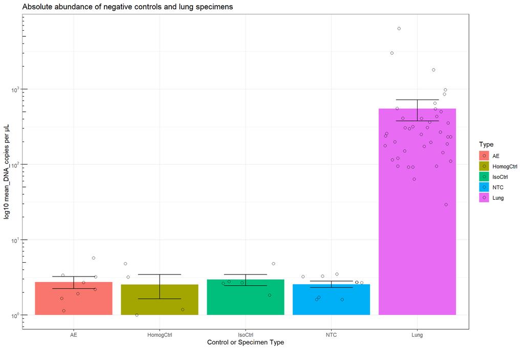

```r
# Create our bar chart using ggplot
ggplot(avg_abs_df, aes(x = Type, y = mean_DNA_copies, fill = Type)) + # This brings in the dataframe and assigns columns to various plot elements
  geom_col() + # The type of plot we want to construct. This is a wrapper for geom_bar(). See ?geom_bar for more details.
  geom_errorbar(aes(ymin = mean_DNA_copies - SEM, ymax = mean_DNA_copies + SEM, width = 0.5)) + # An errorbar layer to be added to the bars
  scale_y_log10(labels = trans_format("log10", math_format(10^.x))) + # We could convert to log10 scale prior to plotting, or we can do it on the fly
  # geom_dotplot(data = abs_df, aes(y = DNA_copies_per_ul), binaxis = "y", dotsize = .6, stackdir = "center", stackratio = 1.5) + # optional
  geom_jitter(data = abs_df, aes(y = DNA_copies_per_ul), shape = 1, size = 2) + # This adds a bit of random noise for visibility of points; shape 1 is an unfilled circle
  theme_bw() + # A minimalist theme
  labs(x = "Control or Specimen Type", y = "log10 mean_DNA_copies per µL", title = "Absolute abundance of negative controls and lung specimens") + # Rename labels
  annotation_logticks(sides = "l") # Control whether/where logticks appear
```

# IV. Comparing Community Composition

There are several tools and methods we can use to compare the makeup of microbial communities.

## 4.1 Visualization techniques

In this subsection we will explore visualization methods including PCA ordinations, biplots, and rank abundance plots (ordered bar charts).

### 4.1.1 PCA Ordination

As a first step, we need to create a PCA model using only the data needed to make our comparison of interest.

#### 4.1.1.a Lung Tissue vs Negative Controls

It’s important to compare the distribution of bacteria present in specimens and negative controls to gauge possible contamination. Let’s construct our first PCA model with a comparison of lung tissue and negative controls in mind.

```r
# Filter data to retain controls and lung tissue only
con_lung_df <- otu_df %>% # Note: this is one of several possible approaches to filtering to retain the correct rows.
  dplyr::filter((reagent_tissue == "Control") | (tissue_type == "Lung")) %>% # 65 specimens
  droplevels() # Remove factor levels with no remaining observations. This prevents potential headaches in downstream data wrangling and visualization.
rownames(con_lung_df) <- con_lung_df$specimen

# PCA of all negative controls + lung tissue
# Keep only the rows of interest for unstandardized data.
otu_con_lung_mat <- otu_good[con_lung_df$specimen, ]
otu_con_lung_hel <- decostand(otu_con_lung_mat, "hellinger") # Standardize: use OTU columns only
otu_con_lung_pca <- rda(otu_con_lung_hel)

# summary() produces a list which is rather messy to print out all at once. Let's just examine the importance of the principal components by accessing $cont
summary(otu_con_lung_pca)$cont # 0.1782 0.08601 0.06845 proportion explained by first 3 axes
```

```
## $importance
## Importance of components:
##                          PC1     PC2     PC3     PC4     PC5     PC6     PC7
## Eigenvalue            0.1448 0.06989 0.05562 0.04892 0.04276 0.02930 0.02854
## Proportion Explained  0.1782 0.08601 0.06845 0.06021 0.05262 0.03606 0.03512
## Cumulative Proportion 0.1782 0.26426 0.33271 0.39292 0.44554 0.48159 0.51672
##                           PC8     PC9    PC10    PC11    PC12    PC13    PC14
## Eigenvalue            0.02439 0.02089 0.02041 0.01800 0.01684 0.01596 0.01459
## Proportion Explained  0.03002 0.02571 0.02511 0.02216 0.02072 0.01964 0.01796
## Cumulative Proportion 0.54674 0.57244 0.59756 0.61972 0.64044 0.66008 0.67804
##                          PC15    PC16    PC17    PC18    PC19    PC20    PC21
## Eigenvalue            0.01392 0.01355 0.01288 0.01230 0.01192 0.01164 0.01080
## Proportion Explained  0.01714 0.01668 0.01586 0.01514 0.01467 0.01433 0.01329
## Cumulative Proportion 0.69517 0.71185 0.72771 0.74284 0.75751 0.77184 0.78513
##                          PC22    PC23     PC24     PC25     PC26     PC27
## Eigenvalue            0.01055 0.01041 0.009766 0.009153 0.008575 0.008428
## Proportion Explained  0.01298 0.01281 0.012019 0.011266 0.010554 0.010373
## Cumulative Proportion 0.79811 0.81092 0.822942 0.834208 0.844762 0.855135
##                           PC28     PC29     PC30     PC31     PC32     PC33
## Eigenvalue            0.008238 0.007763 0.007641 0.006947 0.006804 0.006603
## Proportion Explained  0.010139 0.009554 0.009405 0.008550 0.008373 0.008127
## Cumulative Proportion 0.865273 0.874827 0.884232 0.892782 0.901156 0.909283
##                           PC34     PC35     PC36     PC37     PC38     PC39
## Eigenvalue            0.006321 0.005732 0.005266 0.005048 0.004955 0.004656
## Proportion Explained  0.007779 0.007055 0.006481 0.006213 0.006098 0.005731
## Cumulative Proportion 0.917062 0.924116 0.930597 0.936811 0.942909 0.948640
##                           PC40     PC41     PC42     PC43     PC44     PC45
## Eigenvalue            0.004449 0.004364 0.004106 0.003432 0.003156 0.002749
## Proportion Explained  0.005475 0.005371 0.005054 0.004224 0.003885 0.003384
## Cumulative Proportion 0.954115 0.959486 0.964540 0.968763 0.972648 0.976031
##                           PC46     PC47     PC48     PC49     PC50     PC51
## Eigenvalue            0.002712 0.002402 0.002199 0.001829 0.001720 0.001580
## Proportion Explained  0.003337 0.002956 0.002706 0.002251 0.002117 0.001945
## Cumulative Proportion 0.979369 0.982325 0.985031 0.987282 0.989399 0.991343
##                           PC52     PC53     PC54      PC55      PC56      PC57
## Eigenvalue            0.001185 0.001140 0.001018 0.0007551 0.0006741 0.0005562
## Proportion Explained  0.001459 0.001403 0.001253 0.0009294 0.0008297 0.0006845
## Cumulative Proportion 0.992802 0.994204 0.995457 0.9963865 0.9972162 0.9979008
##                            PC58      PC59      PC60      PC61      PC62
## Eigenvalue            0.0004442 0.0004363 0.0003940 0.0002619 0.0001290
## Proportion Explained  0.0005467 0.0005370 0.0004849 0.0003223 0.0001588
## Cumulative Proportion 0.9984475 0.9989845 0.9994694 0.9997917 0.9999505
##                            PC63      PC64
## Eigenvalue            2.701e-05 1.320e-05
## Proportion Explained  3.325e-05 1.624e-05
## Cumulative Proportion 1.000e+00 1.000e+00
```

```r
# prepare x and y-axis labels
xlab = paste0("PC1 (",round(otu_con_lung_pca$CA$eig[1]/sum(otu_con_lung_pca$CA$eig)*100,2),"% Explained)")
ylab = paste0("PC2 (",round(otu_con_lung_pca$CA$eig[2]/sum(otu_con_lung_pca$CA$eig)*100,2),"% Explained)")
```

Next, we see the corresponding ordination (a spider plot). Clear separation is evident between negative controls and lung specimens along PC1.

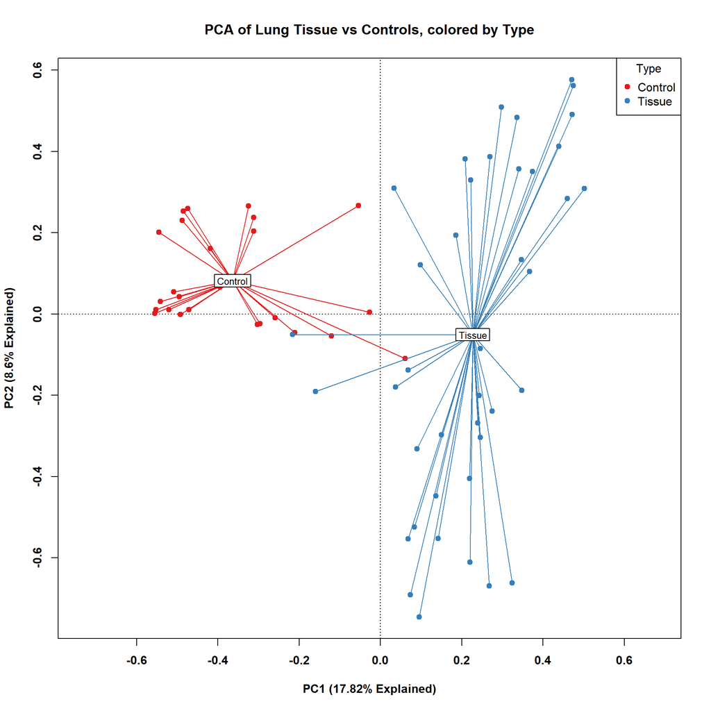

```r
# This approach combines base R plotting functionality and vegan's ordispider function, which creates lines connecting points to the centroids.
# Unlike with ggplot(), these lines of code must all be run at once in order to produce the desired result.
plot(otu_con_lung_pca, type = "n", font = 2, font.lab = 2, xlab = xlab, ylab = ylab, main = "PCA of Lung Tissue vs Controls, colored by Type", display = "sites")
points(otu_con_lung_pca, pch = 19, col = pcapal[as.numeric(con_lung_df$reagent_tissue)]) # pch determines the point shape and col determines the colors to be used.
ordispider(otu_con_lung_pca, con_lung_df$reagent_tissue, label = TRUE, show.groups = c("Control", "Tissue"), col = pcapal[c(1,2)]) # Draw lines from centroids to respective group's points.
legend("topright", levels(con_lung_df$reagent_tissue), pch = 19, col = pcapal, title = "Type") # Format and add details to legends
```

Let’s walk through how we arrived at this visualization, one line at a time. The `plot()` function creates axes based on the dimensions of the data. We also supply axis labels and a title.

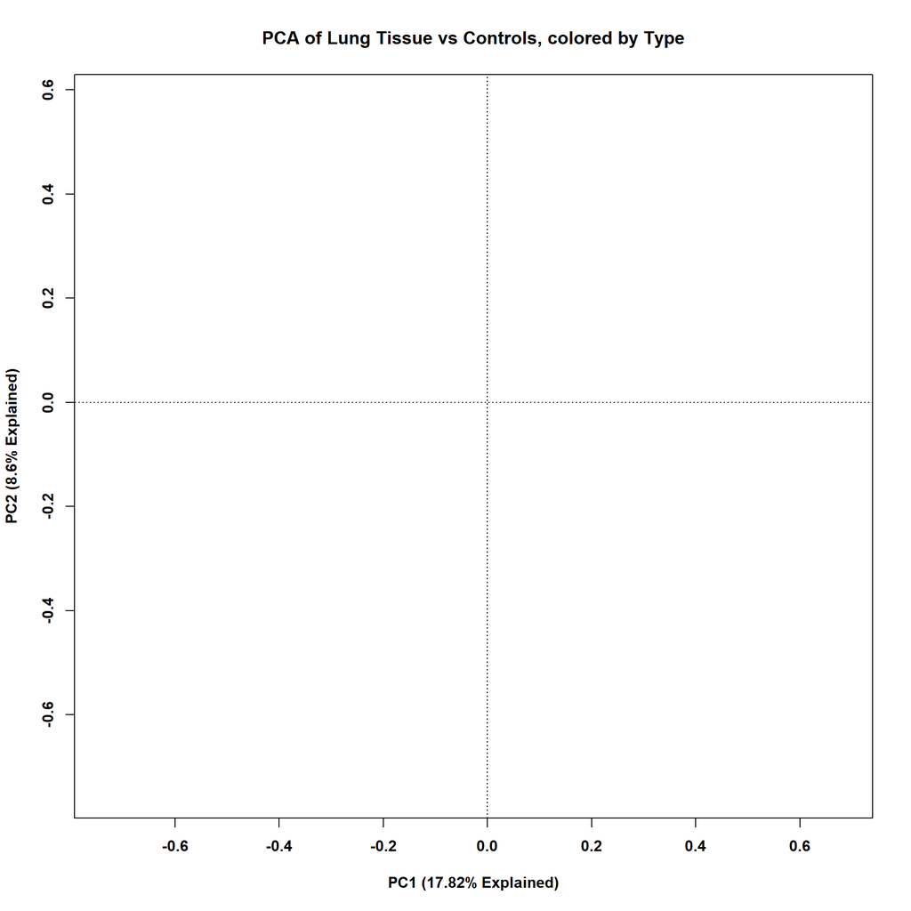

```r
plot(otu_con_lung_pca, type = "n", font = 2, font.lab = 2, xlab = xlab, ylab = ylab, main = "PCA of Lung Tissue vs Controls, colored by Type", display = "sites")
```

Next we’ll add the points with the `points()` function. Note that we’re setting the point shape and color with the `pch` and `col` parameters, respectively. We also have to run both of these lines at the same time to get the desired result.

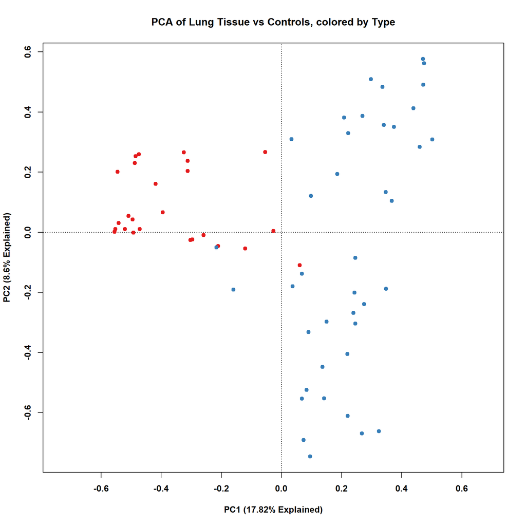

```r
# Unlike with ggplot(), these lines must all be run at once in order to produce the desired result.
plot(otu_con_lung_pca, type = "n", font = 2, font.lab = 2, xlab = xlab, ylab = ylab, main = "PCA of Lung Tissue vs Controls, colored by Type", display = "sites")
points(otu_con_lung_pca, pch = 19, col = pcapal[as.numeric(con_lung_df$reagent_tissue)]) # pch determines the point shape and col determines the colors to be used.
```

We finish the main elements of a spider plot by drawing lines between the points and centroids, done with `ordispider()`. The second argument tells the function which dataframe variable we want to use for the centroids.

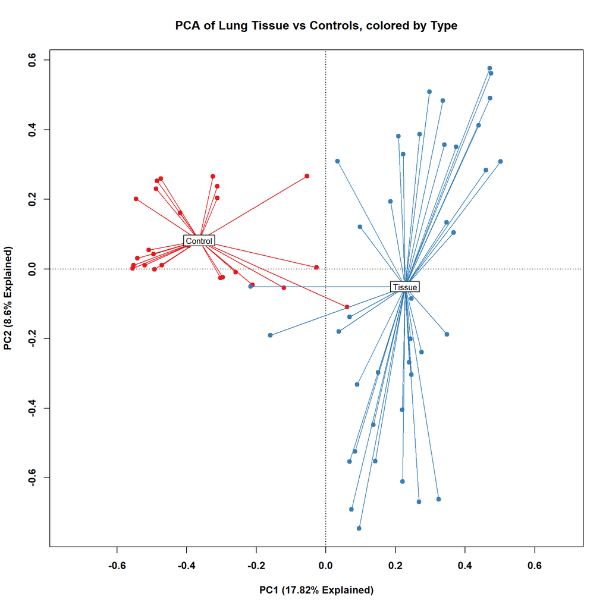

```r
# Unlike with ggplot(), these lines must all be run at once in order to produce the desired result.
plot(otu_con_lung_pca, type = "n", font = 2, font.lab = 2, xlab = xlab, ylab = ylab, main = "PCA of Lung Tissue vs Controls, colored by Type", display = "sites")
points(otu_con_lung_pca, pch = 19, col = pcapal[as.numeric(con_lung_df$reagent_tissue)]) # pch determines the point shape and col determines the colors to be used.
ordispider(otu_con_lung_pca, con_lung_df$reagent_tissue, label = TRUE, show.groups = c("Control", "Tissue"), col = pcapal[c(1,2)]) # Draw lines from centroids to respective group's points.
```

Lastly, we add a legend to arrive at the final figure.

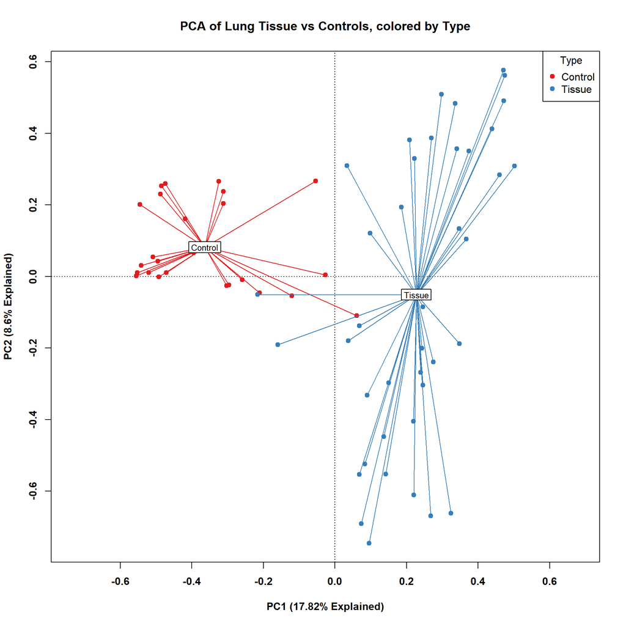

```r
# This approach combines base R plotting functionality and vegan's ordispider function, which creates the lines connecting points to the centroids.
# Unlike with ggplot(), these lines must all be run at once in order to produce the desired result.
plot(otu_con_lung_pca, type = "n", font = 2, font.lab = 2, xlab = xlab, ylab = ylab, main = "PCA of Lung Tissue vs Controls, colored by Type", display = "sites")
points(otu_con_lung_pca, pch = 19, col = pcapal[as.numeric(con_lung_df$reagent_tissue)]) # pch determines the point shape and col determines the colors to be used.
ordispider(otu_con_lung_pca, con_lung_df$reagent_tissue, label = TRUE, show.groups = c("Control", "Tissue"), col = pcapal[c(1,2)]) # Draw lines from centroids to respective group's points.
legend("topright", levels(con_lung_df$reagent_tissue), pch = 19, col = pcapal, title = "Type") # Format and add details to legends
```

`vegan` also supports additional ordinations such as ellipses. Simply adding an `ordiellipse` call with a color parameter (`col`) will give us the following plot. Although other plot customizations could be made, this is where we’ll stop for this example.

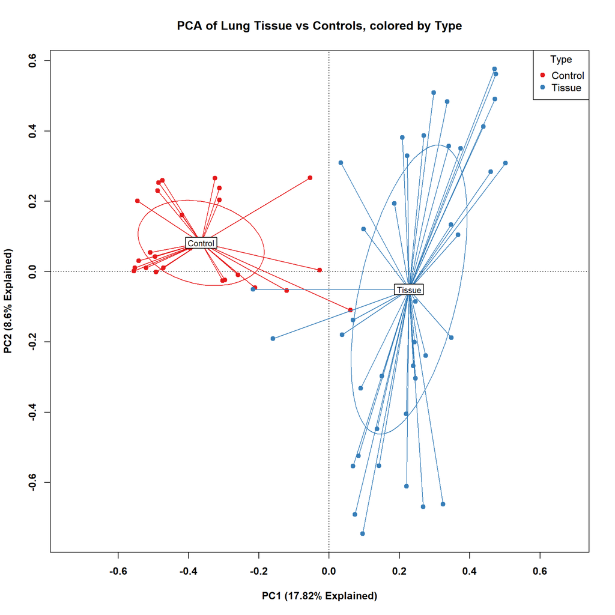

```r
# This is very similar to the previous ordination except that we're drawing ellipses rather than lines connecting the points to the centroids.
plot(otu_con_lung_pca, type = "n", font = 2, font.lab = 2, xlab = xlab, ylab = ylab, main = "PCA of Lung Tissue vs Controls, colored by Type", display = "sites")
points(otu_con_lung_pca, pch = 19, col = pcapal[as.numeric(con_lung_df$reagent_tissue)]) # pch determines the point shape and col determines the colors to be used.
ordispider(otu_con_lung_pca, con_lung_df$reagent_tissue, label = TRUE, show.groups = c("Control", "Tissue"), col = pcapal[c(1,2)]) # Draw lines from centroids to respective group's points.
ordiellipse(otu_con_lung_pca, con_lung_df$reagent_tissue, col = pcapal) # Draw ellipses around the centroids for each group.
legend("topright", levels(con_lung_df$reagent_tissue), pch = 19, col = pcapal, title = "Type") # Format and add details to legends
```

#### 4.1.1.b Biplot

A biplot can help us understand associations between certain microbial features, specimens, specimen groups, and/or principal components. In a biplot, the specimens are represented as points (scores) whereas the features are represented as vectors (loadings). Key points for interpreting biplots:

- Use the cosine of an angle between two features to derive the coefficient of correlation between these features.
- This can also be applied to the angle between a feature and a principal component.
- Longer feature loadings indicate stronger influence on a given PC, whereas 0 length loadings indicate no influence.

Note how Otu0001 and Otu0003 appear to be strongly associated with a subset of negative controls. We see indications of other features aligning with other subsets of specimens.

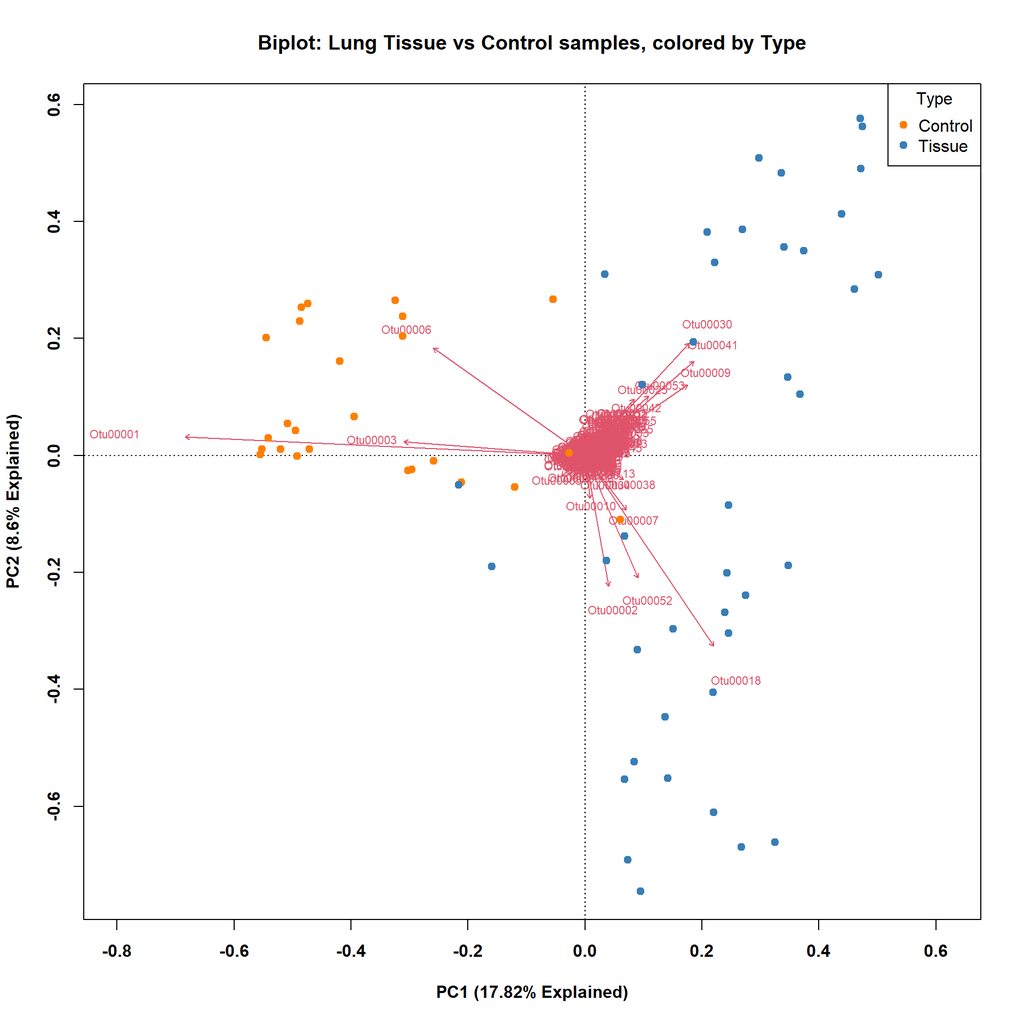

```r
# Consider whether rownames should be shown, if so they may need to be truncated for visibility
# biplot(otu_con_lung_pca, type = "t") # This can result in many warnings if warning=FALSE is not specified above, though it generates the plot it's not recommended

# Address warnings with the following function, (hides warnings from 0-length arrows)
# Alternatively, set warning=FALSE in the code chunk; does not seem to work on macs in older R/package versions
quiet_biplot <- quietly(function(ordiobj, ...) {
  biplot(ordiobj, ...)
})

# Basic example: this can become difficult to read with many long specimen identifiers
# biplot_results <- quiet_biplot(otu_con_lung_pca, type = "t")

# A better approach is to use points color coded by the classes of interest as an additional layer on top of the biplot arrows
biplot_results <- quiet_biplot(otu_con_lung_pca, type = "t", font = 2, font.lab = 2, xlab = xlab, ylab = ylab,
                               main = "Biplot: Lung Tissue vs Control samples, colored by Type", display = "species", xlim = c(-0.8, 0.62)) # Note, plot zoom for xlim/ylim may need to be adjusted due to changing the display parameter
points(otu_con_lung_pca, pch = 19, col = pcapal[c(5,2)][as.numeric(con_lung_df$reagent_tissue)]) # color palette adjusted to conflict less with biplot arrows
legend("topright", levels(con_lung_df$reagent_tissue), pch = 19, col = pcapal[c(5,2)], title = "Type") # adjust legend color pal to match points
```

```r
# Another example for replacing specimen labels with C or T
# biplot(prcomp(otu_con_lung_hel), xlabs=ifelse(str_detect(con_lung_df$reagent_tissue, "Control"), "C", "T")) # arrow.len = 0 will also remove warnings, at the cost of losing the arrowhead
```

#### 4.1.1.c Lung Tissue: Charles River vs Jackson Labs

In our original experiment, we compared murine specimens from Charles River and Jackson Labs. Let’s create a second PCA model to contrast lung specimens across vendors.

```r
# Filter data to retain lung tissue only
otu_lung_df <- dplyr::filter(otu_df, tissue_type == "Lung") %>%
  droplevels() # remove levels corresponding to data that is no longer present due to filtering
rownames(otu_lung_df) <- otu_lung_df$specimen

# PCA of lung tissue specimens
# Keep only the rows of interest for unstandardized data.
otu_lung_mat <- otu_good[otu_lung_df$specimen, ]
otu_lung_hel <- decostand(otu_lung_mat, "hellinger") # Standardize use OTU columns only
otu_lung_pca <- rda(otu_lung_hel)

# summary() produces a list which is rather messy to print out all at once. Let's just examine the importance of the principal components by accessing $cont
summary(otu_lung_pca)$cont # 0.1458 0.10677 0.06776 proportion explained by first 3 axes
```

```
## $importance
## Importance of components:
##                          PC1     PC2     PC3     PC4     PC5     PC6     PC7
## Eigenvalue            0.1190 0.08712 0.05529 0.04696 0.03976 0.03475 0.03389
## Proportion Explained  0.1458 0.10677 0.06776 0.05755 0.04873 0.04259 0.04153
## Cumulative Proportion 0.1458 0.25258 0.32034 0.37790 0.42662 0.46921 0.51075
##                           PC8     PC9    PC10    PC11    PC12    PC13    PC14
## Eigenvalue            0.02572 0.02484 0.02339 0.02110 0.02078 0.01959 0.01914
## Proportion Explained  0.03152 0.03045 0.02867 0.02587 0.02546 0.02401 0.02345
## Cumulative Proportion 0.54226 0.57271 0.60138 0.62724 0.65271 0.67672 0.70017
##                          PC15    PC16    PC17    PC18    PC19    PC20    PC21
## Eigenvalue            0.01861 0.01847 0.01686 0.01579 0.01481 0.01445 0.01370
## Proportion Explained  0.02280 0.02264 0.02066 0.01935 0.01815 0.01771 0.01679
## Cumulative Proportion 0.72297 0.74561 0.76627 0.78563 0.80378 0.82149 0.83828
##                          PC22    PC23    PC24    PC25    PC26     PC27     PC28
## Eigenvalue            0.01274 0.01267 0.01224 0.01120 0.01069 0.009415 0.009183
## Proportion Explained  0.01561 0.01552 0.01500 0.01372 0.01310 0.011539 0.011255
## Cumulative Proportion 0.85390 0.86942 0.88442 0.89814 0.91124 0.922779 0.934034
##                           PC29     PC30     PC31     PC32     PC33     PC34
## Eigenvalue            0.008479 0.007690 0.007462 0.006652 0.006510 0.004720
## Proportion Explained  0.010392 0.009424 0.009145 0.008152 0.007978 0.005784
## Cumulative Proportion 0.944425 0.953850 0.962995 0.971147 0.979125 0.984910
##                           PC35     PC36     PC37     PC38      PC39
## Eigenvalue            0.004444 0.003119 0.002280 0.001560 0.0009102
## Proportion Explained  0.005447 0.003822 0.002794 0.001912 0.0011155
## Cumulative Proportion 0.990356 0.994178 0.996973 0.998885 1.0000000
```

```r
# prepare x and y-axis labels
xlab = paste0("PC1 (",round(otu_lung_pca$CA$eig[1]/sum(otu_lung_pca$CA$eig)*100,2),"% Explained)")
ylab = paste0("PC2 (",round(otu_lung_pca$CA$eig[2]/sum(otu_lung_pca$CA$eig)*100,2),"% Explained)")
```

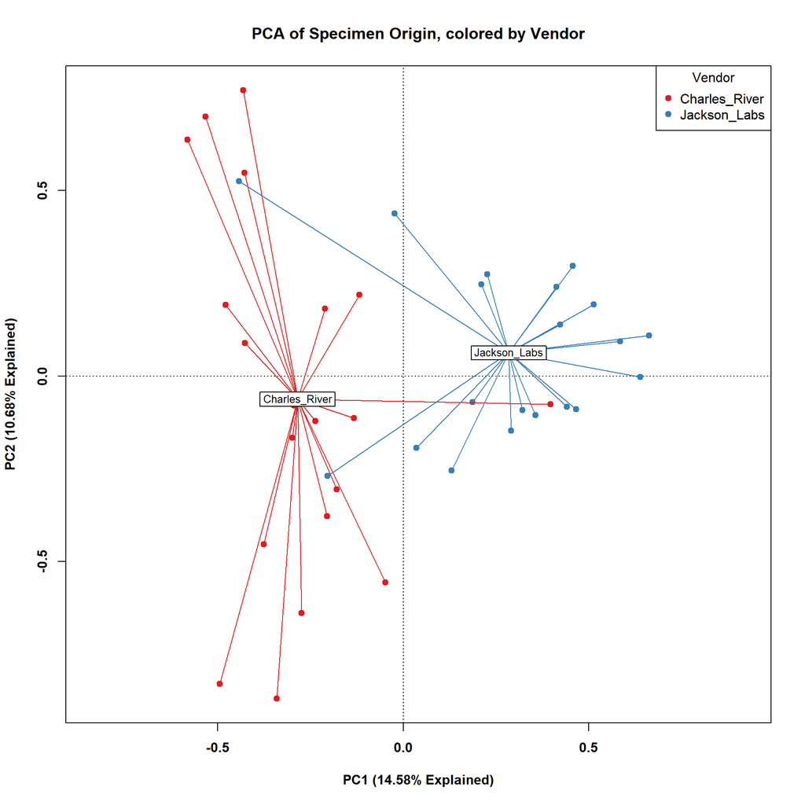

```r
# This approach combines base R plotting functionality and vegan's ordispider function, which creates the lines connecting points to the centroids.
# Unlike with ggplot(), these lines must all be run at once in order to produce the desired result.
plot(otu_lung_pca, type = "n", font = 2, font.lab = 2, xlab = xlab, ylab = ylab, main = "PCA of Specimen Origin, colored by Vendor", display = "sites")
points(otu_lung_pca, pch = 19, col = pcapal[as.numeric(otu_lung_df$vendor)]) # pch determines the point shape and col determines the colors to be used.
ordispider(otu_lung_pca, otu_lung_df$vendor, label = TRUE,  show.groups = c("Charles_River", "Jackson_Labs"), col = pcapal[c(1,2)]) # Draw lines from centroids to respective group's points.
legend("topright", levels(otu_lung_df$vendor), pch = 19, col = pcapal, title = "Vendor") # Format and add details to legends
```

#### 4.1.1.d Biplot

The PCA ordination of lung samples by vendor again shows clear separation of specimens by PC1 (though remember that this PC1 differs from the lung vs control PC1). Next, we’ll examine another biplot using only lung specimens. Optional: uncomment the other biplot code to examine alternative approaches. Interestingly, we see that Otu0018 and Otu00052 are clearly negatively associated along PC2. This is in contrast to the negative control vs lung tissue biplot where these features had similar angles and lengths along PC1 and PC2.

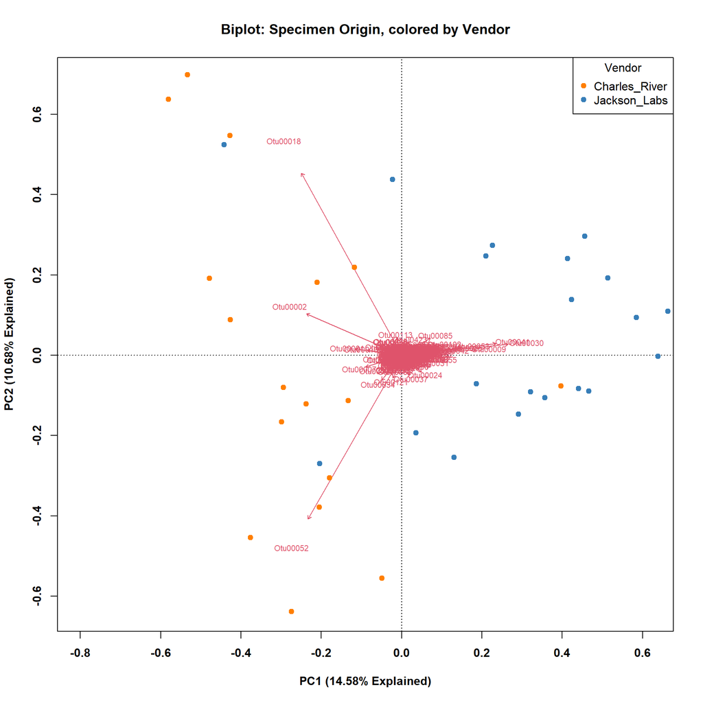

```r
# Consider whether rownames should be shown, if so they may need to be truncated for visibility

# biplot(otu_lung_pca, type = "t") # This will result in a lot of warnings, and though it generates the plot it's not recommended

# Address warnings with the following function, (hides warnings from 0-length arrows)
# Alternatively, set warning=FALSE in the code chunk; does not seem to work on macs

# see function that was created previously
# biplot_results <- quiet_biplot(otu_lung_pca, type = "t")

biplot_results <- quiet_biplot(otu_lung_pca, type = "t", font = 2, font.lab = 2, xlab = xlab, ylab = ylab,
                               main = "Biplot: Specimen Origin, colored by Vendor", display = "species", xlim = c(-0.8, 0.62)) # Note, plot zoom for xlim/ylim may need to be adjusted due to changing the display parameter
points(otu_lung_pca, pch = 19, col = pcapal[c(5,2)][as.numeric(otu_lung_df$vendor)]) # color palette adjusted to conflict less with biplot arrows
legend("topright", levels(otu_lung_df$vendor), pch = 19, col = pcapal[c(5,2)], title = "Vendor")
```

```r
# example for replacing specimen labels with CR or JL
# biplot(prcomp(otu_lung_hel), xlabs=ifelse(str_detect(otu_lung_df$vendor, "Charles_River"), "CR", "JL")) # arrow.len = 0 will also remove warnings, at the cost of losing the arrowhead
```

#### 4.1.1.e Point Scaling and Plotting other Principal Components

Optional: See Supplemental (9.1.1.a and b) to learn about point scaling and plotting other Principal Components in PCA ordinations.

### 4.1.2 Rank Abundance

In the following series of examples, we’ll use Rank Abundance (RA) plots to compare the community composition in lung specimens against negative controls. Note that the strategies we’ll use can be extended to conduct comparisons across any arbitrary groups, assuming metadata exists to identify the observations (rows) belonging to each group. For instance, we might compare four different types of tissue, or drill down into the controls and compare those subtypes.

#### 4.1.2.a Comparison of Negative Controls against Lung Tisssue specimens

```r
# First we need to prepare the data: negative controls and lung tissue specimens
# Order the data by most abundant OTU in lung tissue specimens only
# Include an errorbar
# Color by phyla

ra_df <- otu_df %>% # Note that this is one of several possible approaches to filtering to retain the correct rows
  dplyr::filter((reagent_tissue == "Control") | (tissue_type == "Lung")) %>% # 65 specimens
  droplevels() # remove factor levels with no remaining observations - saves potential headaches in downstream wrangling and visualizations

# Determine the order of OTUs based on means within Lung specimens
otu_order <- names(sort(colMeans(dplyr::filter(ra_df, tissue_type == "Lung")[, str_detect(colnames(ra_df), "Otu")]), decreasing = TRUE))

# Keep top 20 OTUs, then reshape the dataframe from wide to long format
g_df <- ra_df %>%
  dplyr::select(str_which(colnames(ra_df), "Otu", negate = TRUE), colnames(ra_df[, otu_order[1:20]])) %>% # Keep non-OTU columns, followed by the 20 most abundant OTUs
  pivot_longer(cols = -str_which(colnames(ra_df), "Otu", negate = TRUE), names_to = "OTU", values_to = "Percentage",
               names_ptypes = list(OTU = factor(levels = otu_order[1:20]))) # Ensuring OTU column is a factor is important due to the ordering expected in RA plots

# Join Phylum column from taxonomy table
tax_df <- otu_good_taxonomy[otu_good_taxonomy[,"OTU"] %in% otu_order[1:20], c("OTU", "Phylum")] # Keep only the rows from ranked OTU vector, and OTU + whatever taxonomic level to use for filling bars
tax_df$OTU <- factor(tax_df$OTU, levels = otu_order[1:20]) # set OTU factor levels to be in the same order as in g_df. If this is not done, our OTU column will be coerced to a character vector when we join (we'll lose the factor levels)
g_df <- inner_join(g_df, tax_df, by = "OTU")

# dimg(g_df) # dimensions have gone from 65 745 to 1300 18

# Generate mean and sem for each group
con_lung_agg_df <- g_df %>%
  group_by(reagent_tissue, OTU, Phylum) %>%
  summarize(Mean_perc = mean(Percentage), SEM = sqrt(var(Percentage)/length(Percentage)), .groups = "drop")
```

First we’ll create a basic rank abundance plot, then it will be gradually enhanced in the following examples. A plot can be saved to a variable, such as `p` in this case. Wrapping the code in `()` enables the output to be saved to `p` and viewed at the same time.

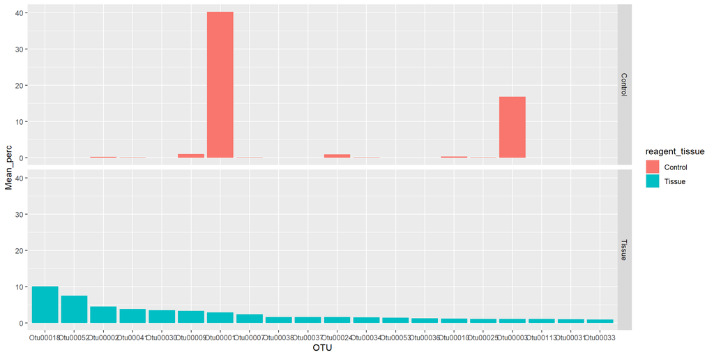

```r
(p <- ggplot(con_lung_agg_df, aes(x = OTU, y = Mean_perc, fill = reagent_tissue)) + # Utilize the data and map the variables to plot parameters.
  geom_col() +
  facet_grid(reagent_tissue ~ .)) # Faceting replicates the plot once for each category contained within specified variable(s).
```

Let’s add an errorbar and improve the visual aesthetics.

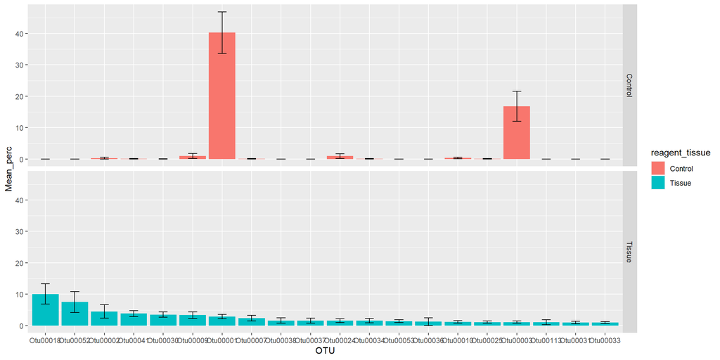

```r
# Add an errorbar
(q <- p + geom_errorbar(aes(ymin = Mean_perc - SEM, ymax = Mean_perc + SEM, width = 0.3)))
```

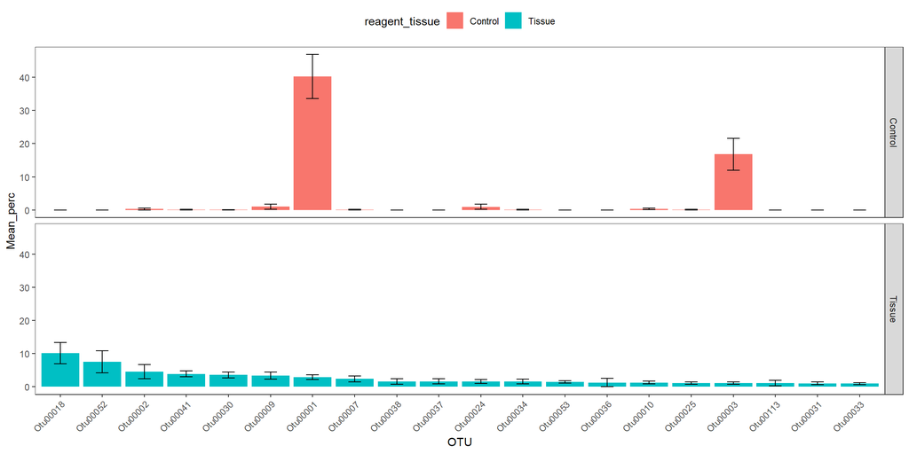

```r
# Clear background + modify theme (rotate x-axis labels, reposition legend)
(q <- q + theme_bw() + # note that a theme layer added after other other theme modifications will remove these prior modifications
    theme(panel.grid = element_blank(), axis.text.x = element_text(angle = 45, hjust = 1), legend.position = "top"))
```

Add Genus labels to OTU identifiers to improve feature interpretation.

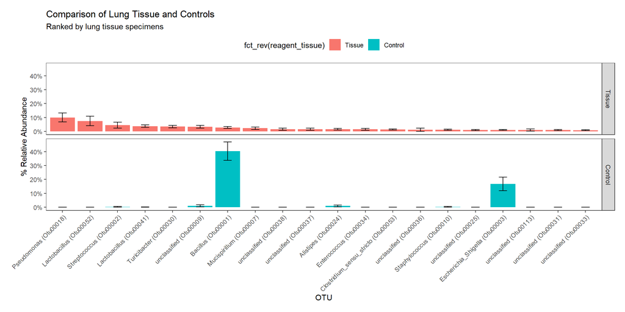

```r
# Add Genus levels to the OTU Number
levels(con_lung_agg_df$OTU) <- fct_inorder(paste0(otu_good_taxonomy[levels(con_lung_agg_df$OTU), ]$Genus, " (", levels(con_lung_agg_df$OTU), ")"))
# equivalent to: # cbmbtools::paste_tax(levels(agg_df$OTU))

ggplot(con_lung_agg_df, aes(x = OTU, y = Mean_perc, fill = fct_rev(reagent_tissue))) +
  geom_col() +
  facet_grid(fct_rev(reagent_tissue) ~ .) + # use fct_rev to place Tissue first, which is what we've sorted OTUs by
  geom_errorbar(aes(ymin = Mean_perc - SEM, ymax = Mean_perc + SEM, width = 0.3)) +
  theme_bw() +
  theme(panel.grid = element_blank(), axis.text.x = element_text(angle = 45, hjust = 1), legend.position = "top", plot.margin = unit(c(0.5,0.5,0.5,1),"cm")) +
  scale_y_continuous(labels = unit_format(suffix = "%")) +
  labs(title="Comparison of Lung Tissue and Controls", subtitle = "Ranked by lung tissue specimens", y = "% Relative Abundance")
```

How do we adjust the legend and facet labels?

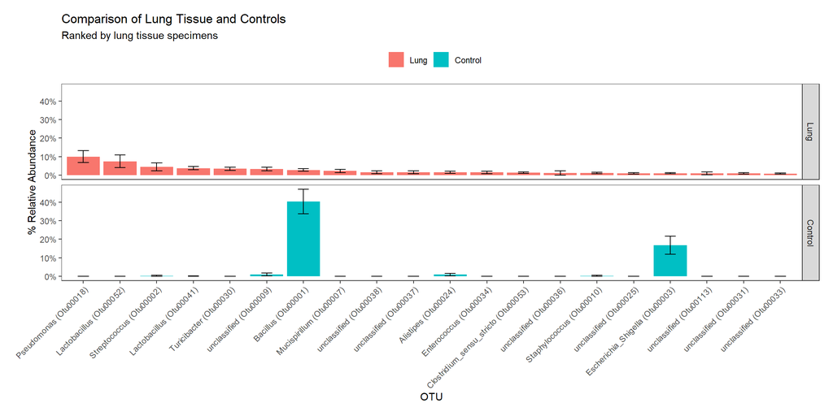

```r
# Although it is possible to adjust the values and labels within the ggplot workflow, perhaps the simplest approach would be to correct the reagent_tissue column values and factor levels prior to plotting
con_lung_agg_df$reagent_tissue <- fct_recode(con_lung_agg_df$reagent_tissue, Lung = "Tissue") %>%
  fct_relevel("Lung")

ggplot(con_lung_agg_df, aes(x = OTU, y = Mean_perc, fill = reagent_tissue)) +
  geom_col() + # use show.legend = FALSE to remove the legend entirely
  facet_grid(reagent_tissue ~ .) +
  geom_errorbar(aes(ymin = Mean_perc - SEM, ymax = Mean_perc + SEM, width = 0.3)) +
  theme_bw() +
  theme(panel.grid = element_blank(), axis.text.x = element_text(angle = 45, hjust = 1), legend.position = "top", plot.margin = unit(c(0.5,0.5,0.5,1),"cm"),
        legend.title = element_blank()) +
  scale_y_continuous(labels = unit_format(suffix = "%")) +
  labs(title="Comparison of Lung Tissue and Controls", subtitle = "Ranked by lung tissue specimens", y = "% Relative Abundance")
```

```r
  # for further customizing of the legend, try adding a guide_legend() layer
```

How can we use fill color to show the phyla to which each OTU belongs?

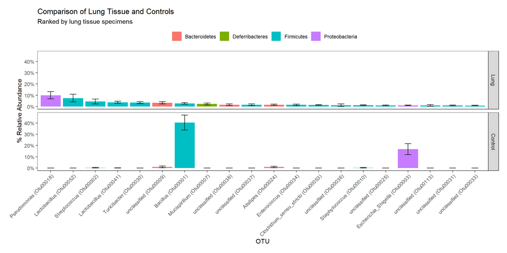

```r
# First we need to prepare the taxonomic data. In this case we did this earlier in our overall RA data prep.
# Next, simply change the fill parameter to Phylum and rerun the ggplot code
ggplot(con_lung_agg_df, aes(x = OTU, y = Mean_perc, fill = Phylum)) +
  geom_col() + # use show.legend = FALSE to remove the legend entirely
  facet_grid(reagent_tissue ~ .) +
  geom_errorbar(aes(ymin = Mean_perc - SEM, ymax = Mean_perc + SEM, width = 0.3)) +
  theme_bw() +
  theme(panel.grid = element_blank(), axis.text.x = element_text(angle = 45, hjust = 1), legend.position = "top", plot.margin = unit(c(0.5,0.5,0.5,1),"cm"),
        legend.title = element_blank()) +
  scale_y_continuous(labels = unit_format(suffix = "%")) +
  labs(title="Comparison of Lung Tissue and Controls", subtitle = "Ranked by lung tissue specimens", y = "% Relative Abundance")
```

```r
# Try to experiment with the above code by running it again after commenting out a layer, or altering 1 parameter. This will help you to develop a deeper understanding of how to build up or alter a ggplot object.
```